# Tale of Two Studies

Quantitative enablement of smart risk-taking in clinical study design

Andrew Bean (Advanced Quantitative Sciences, Novartis Pharmaceuticals, East Hanover, NJ USA)

EFSPI SSL Webinar

2025-05-06

## Background

- PoS framework of Hampson, Bornkamp, et al. (2022) is well established at Novartis
  - Quantification of **program-level risk**
  - Goals include: **transparency** with project- and portfolio-level stakeholders
- Study-level predictions are based on expert prior elictation (e.g. Holzhauer et al. (2022)) or on the predictive distribution from a Bayesian meta-analysis model

## Today’s talk

- Two examples where a deeper dive into study-level unknowns was beneficial
  - Quantification of **study-level risk**
  - Useful for **project-level decision-making**
- Tailored modelling to answer the question “how likely is my study to succeed?”

# How likely is my pivotal program to succeed?

## Program-level PoS approach

### Bringing in all relevant information

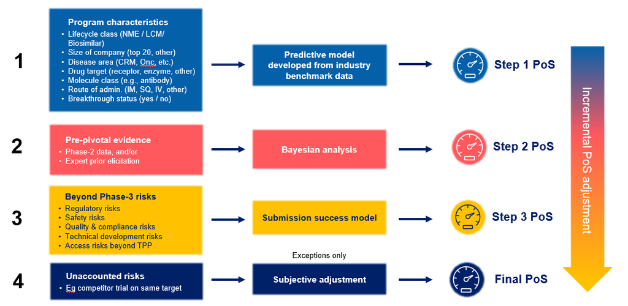

Steps to a program-level evaluation using the Hampson, Bornkamp, et al. (2022) approach

## Program-level PoS approach

### Outcome of an assessment

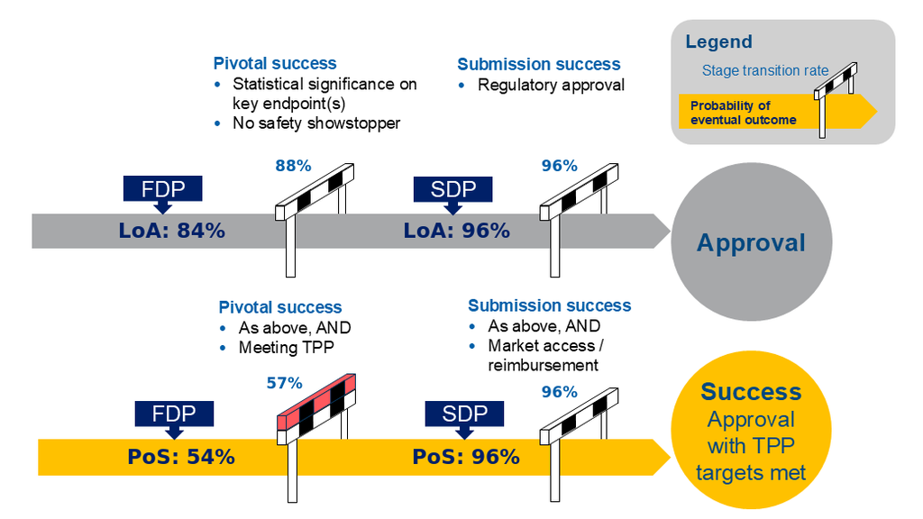

Probability of success to approval (top), and with additional requirement of meeting Target Product Profile (TPP) met (bottom). Paths show P(success) and hurdles show transition rates.

## Program-level PoS approach

### References

This PoS framework has been described in

- Hampson, Bornkamp, et al. (2022)
- Hampson, Holzhauer, et al. (2022)
- Holzhauer et al. (2022)

and presented many times, including:

- BAYES2023 (Hampson 2023)
- DSBS/FMS meeting (Lange 2022)
- DIA BSWG (Hampson and Holzhauer 2021)
- BBS seminar (Lange 2021)

# How likely is my trial to succeed?

## Flow of efficacy predictions<sup>1</sup>

From a **calibrated benchmark prior** (for the mean effect)
$$p(\mu) = w_t N(m_t, c) + (1 - w_t) N(m_n, c)$$
… to the **posterior distribution** (for the mean effect),
$$p(\mu,\tau | \{ \hat\theta_i, s_i \}) \propto \prod_i f(\hat\theta_i | \theta_i) p(\theta_i | \mu,\tau) \cdot p(\mu) \, p(\tau)$$
… the **MAP<sup>2</sup> prior** (for a future study mean),
$$p(\theta^* \, | \, \{ \hat\theta_i, s_i \}) = \int \text{N}(\theta^* | \mu,\tau)\, dP(\mu,\tau | \{ \hat\theta_i, s_i \})$$
… and the **predictive distribution** (for a future study outcome),
$$p(\hat\theta^* \, | \, \{ \hat\theta_i, s_i \}) = \int \text{N}(\hat\theta^* | \theta^*, s^*)\, dP(\theta^* \, | \, \{ \hat\theta_i, s_i \})$$

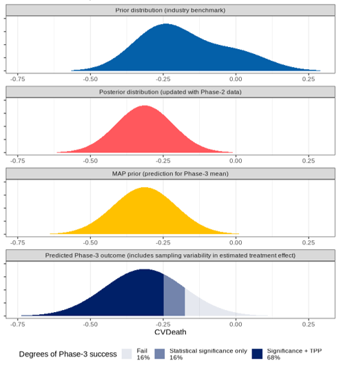

[^1]: Hampson, Bornkamp, et al. (2022)
[^2]: Meta-Analytic Predictive prior, see Neuenschwander et al. (2010)

# Two studies

## Study 1

#### Design: Phase 3b H2H non-inferiority study

```
flowchart LR
  A[Eligible patients] --> B(1:1 randomize)
  B --> C[Investigational drug]
  B --> D[Competitor drug]
  C --> E(Test non-inferiority)
  D --> E
```

#### Timing: two options

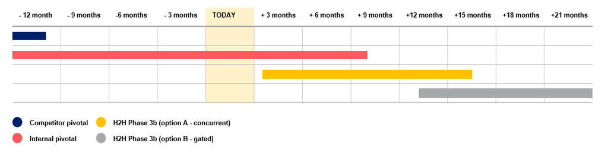

Options for timing of H2H Phase-3b: (A) before pivotal readout or (B) gated on positive pivotal

## Study 1: Strategy

#### What is “success”?

- Prerequisite: Pivotal success (supriority to SoC)
- Required: H2H noninferiority
- Desired: H2H (numerical) superiority

#### What are the risks?

- Commercial impact of failure
- Challenging: choice of noninferiority margin
- Risks magnified for concurrent Phase-3b due to incomplete information at design stage

## Study 1: Enabling smart risks

#### Strategic decision makers would need to know:

- What are plausible head-to-head effects based on what we know now?
- How much additional risk from beginning Phase-3b concurrently as opposed to waiting on positive Phase-3?

## Study 1: Quantifying risks

### Inadequacy of power alone

- Consider a study concept with sample size chosen to ensure 90% power to declare noninferiority (at a specified margin) given true head-to-head effect of zero
- Does this adequately capture the level of risk? NO!
- Several inputs to this calculation are based on uncertain quantities

## Study 1: Quantifying risks

### Uncertainty about H2H effect

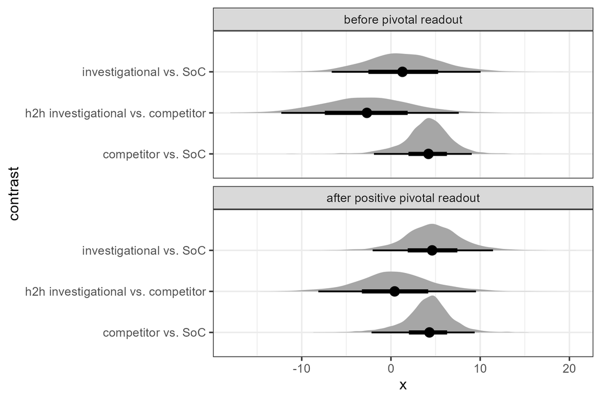

#### Two versions of contrast-based network meta-analysis

- Using what is known now (risk of concurrent trial)<sup>1</sup>
- Using what *will be known* after pivotal results (risk of gated trial)<sup>2</sup>
[^3]: Using benchmark-based prior for investigational effect vs. SoC
[^4]: Adding a right-censored pivotal outcome to the likelihood

## Study 1: Communicating risks

#### Option A: go now w/ current knowledge

| Pivotal outcome (random) | Phase 3b outcome | Total probability |
| --- | --- | --- |
| Success (74%) | Success (83%) | 61% |
|  | Failure (17%) | 13% |
| Failure (26%) | Unimportant | 26% |

#### Option B: await pivotal outcome

| Pivotal outcome (known) | Phase 3b outcome | Total probability |
| --- | --- | --- |
| Success | Success (83%) | 83% |
|  | Failure (17%) | 17% |
| Failure | Not run | N/A |

## Study 2

### Impact of nonresponder imputation

#### Design

```
flowchart LR
  A[Eligible patients] --> A1[Adult patients]
  A --> A2[Pediatric patients]
  A1 --> B1(1:1 randomize)
  A2 --> B2(1:1 randomize)
  B1 --> D[Investigational]
  B1 --> E[Standard-of-Care]
  B2 --> D
  B2 --> E
  D --> F(Test for superiority)
  E --> F
```

#### Key Consideration

- **Nonresponder imputation** for patients dropping out due to lack of tolerability
- Dropout rate anticipated **higher on the investigational treatment**, especially among **pediatric patients**

## Study 2: Strategy

#### What is “success”?

- Required: Superiority overall
- Desired: Superiority in both adults and pediatric patients

#### What are the risks?

- Attenuation of treatment effect due to differential dropout rates
- Higher degree of uncertainty about pediatric effects (pre-pivotal data is from adults)

## Study 2: Quantifying risks

### Inadequacy of power

#### Typical presentation: power under various scenarios

[output not shown]

#### Shortcoming

What is the relative plausibility of these scenarios based on what we know?

## Study 2: Quantifying risks

### Modelling **all** unknowns

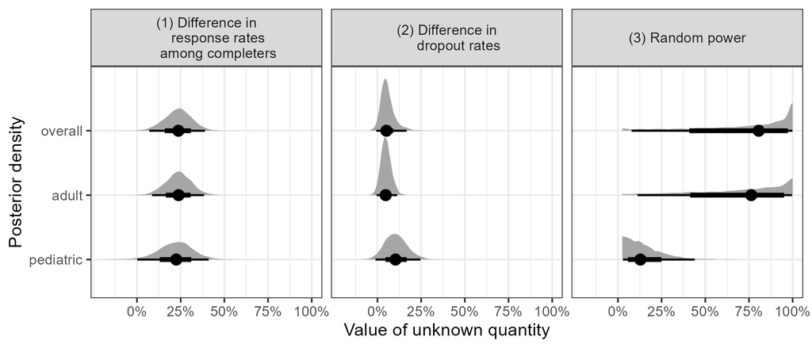

Separate meta-analytic modelling of historical data for (1) treatment effect among completers, (2) dropout rates + elicited beliefs about pediatric dropout, and (3) posterior distribution of power function implied under theese models

## Study 2: Communicating risks

### Visual display: sensitivity of power

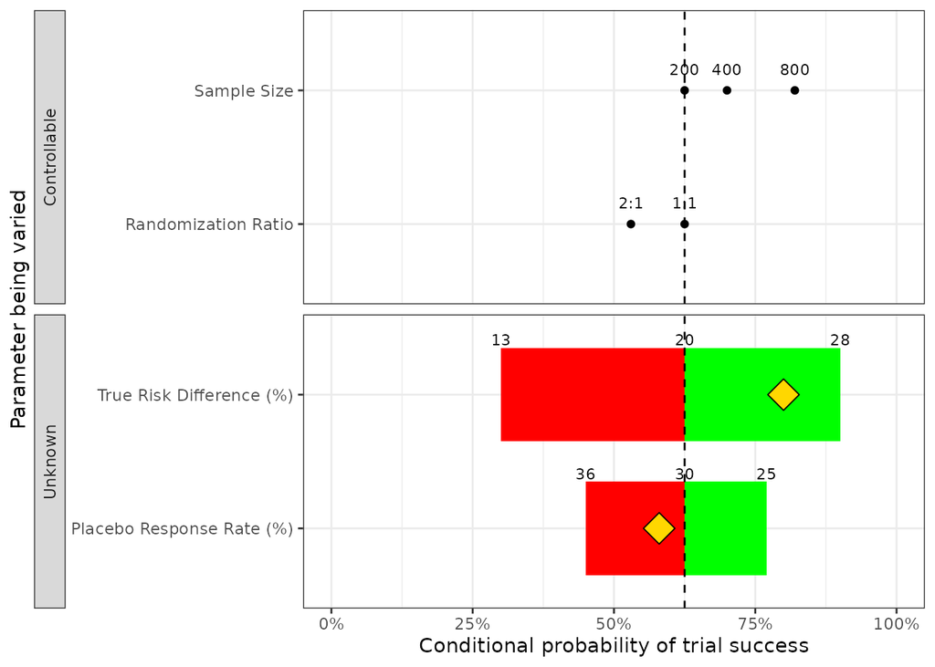

Example of a **tornado plot** illustrating systematic sensitivity analysis of power. Bounds for unknowns are calibrated based on degree of certainty (central 50% posterior intervals). Diamonds represent values assumed in sample-size calculation.

# Conclusions

## Themes

- Understanding, quantifying, and communicating about risks in study design
- Power alone does not sufficiently characterize risk in these cases
- A slightly different emphasis than program-level PoS: more granular attention to study-specific considerations
  - Especially necessary outside pivotal Phase 3
  - e.g. in Study 1, calibrated benchmark prior is not directly relevant to the H2H effect

## A PoS philosophy

- **Modelling** when there is data
  - Potentially going beyond treatment effect: e.g. standard deviations, control response rates, overdispersion etc.
- **Eliciting** to bridge data gaps
  - SHELF framework has been powerful (Holzhauer et al. 2022)
- **Sensitivity** for controllables
  - Sample size, timing of assessment, estimands
- **Standardization** as much as possible
  - Consistent communication AND methods

## Acknowledgements

#### Quantitative PoS team, including

- Markus Lange
- Björn Holzhauer
- Joseph Kahn
- Alex Przybylski
- Lou Whitehead
- Steffen Ballerstedt

#### And other colleagues

- Lisa Hampson
- Jahangir Alam
- David Ohlssen
- Andrew Wright
- Guoqin Su
- Gen Zhu
- Haoyi Fu

## References

Hampson, Lisa V. 2023. “Role of Bayesian Methods in Evaluating and Communicating Risk.” In *BAYES2023 Conference*. Utrecht, Netherlands. https://www.bayes-pharma.org/wp-content/uploads/2023/11/22-HAMPSON-Quantitative-Decision-Making-for-drug-development-the-role-of-Bayesian-methods-in-evaluating-and-communicating-risk.pdf.

Hampson, Lisa V., Björn Bornkamp, Björn Holzhauer, Joseph Kahn, Markus R. Lange, Wen-Lin Luo, Giovanni Della Cioppa, Kelvin Stott, and Steffen Ballerstedt. 2022. “Improving the Assessment of the Probability of Success in Late Stage Drug Development.” *Pharmaceutical Statistics* 21 (2): 439–59. https://doi.org/https://doi.org/10.1002/pst.2179.

Hampson, Lisa V., and Björn Holzhauer. 2021. “Strategies for Improving the Assessment of the Probability of Success in Late Stage Drug Development.” In *Bayesian Scientific Working Group (BSWG) KOL Series 21*. https://view.officeapps.live.com/op/view.aspx?src=http%3A%2F%2Fwww.bayesianscientific.org%2Fwp-content%2Fuploads%2F2021%2F02%2FDIA_Hampson_Holzhauer_Feb2021.pptx&wdOrigin=BROWSELINK.

Hampson, Lisa V., Björn Holzhauer, Björn Bornkamp, Joseph Kahn, Markus R. Lange, Wen-Lin Luo, Pritibha Singh, Steffen Ballerstedt, and Giovanni Della Cioppa. 2022. “A New Comprehensive Approach to Assess the Probability of Success of Development Programs Before Pivotal Trials.” *Clinical Pharmacology & Therapeutics* 111 (5): 1050–60. https://doi.org/https://doi.org/10.1002/cpt.2488.

Holzhauer, Björn, Lisa V. Hampson, John Paul Gosling, Björn Bornkamp, Joseph Kahn, Markus R. Lange, Wen-Lin Luo, et al. 2022. “Eliciting Judgements about Dependent Quantities of Interest: The SHeffield ELicitation Framework Extension and Copula Methods Illustrated Using an Asthma Case Study.” *Pharmaceutical Statistics* 21 (5): 1005–21. https://doi.org/https://doi.org/10.1002/pst.2212.

Lange, Markus. 2021. “Unraveling a Single Number: Using Graphics to Explain Probability of Success.” In *Basel Biometrics Society (BBS) Seminar*. https://baselbiometrics.github.io/home/docs/talks/20210308/5_Lange.pdf.

———. 2022. “Strategies for Improving the Assessment of Probability of Success (PoS) in Late Stage Drug Development.” In *Joint DSBS/FMS Meeting 2022*. Copenhagen, Denmark. https://statistikframjandet.se/wp-content/uploads/2022/12/Markus-Lange-Strategies-for-improving-the-assessment-of-probability-of-success-PoS-in-late-stage-drug-development.pdf.

Neuenschwander, Beat, Gorana Capkun-Niggli, Michael Branson, and David J Spiegelhalter. 2010. “Summarizing Historical Information on Controls in Clinical Trials.” *Clinical Trials* 7 (1): 5–18. https://doi.org/10.1177/1740774509356002.